# Geographic Data Science for Public Policy

Francisco Rowe ([`@fcorowe`](http://twitter.com/fcorowe))

2021-11-12

# Description

This course offers an introduction to *Geographic Data Science for Public Policy*. It provides a general framework to develop understanding of the ways in which geographic data analytics can be used to turn raw data into actionable information that can inform decision making. The course adopts a problem-to-solution teaching approach, defining a practical problem and illustrating how geographic data science can enable understanding to make critically informed decisions. It uses a learning-by-doing approach based on real-world examples. This also teaches how to conduct statistical and geographic data analysis in *R*.

# Aims

This module aims to provide an introduction to geographic data science and illustrate how geographic data science data can be used to produce evidence and inform decision making:

- Understand how geographic data science can support data-driven decision making;
- Provide an understanding of the core principles of geographic data science;
- Offer programming and technical skills to apply geographic data science;
- Develop skills to enable you to identify a significant research or applied problem;
- Apply geographic data science to real-world examples.

# Learning outcomes

By the end of the module, you should be able to:

- Demonstrate understanding of core geographic data science concepts and tools;
- Understand how to programmatically import, manipulate, visualise, map and analyse geographic data frames;
- Apply geographic modelling techniques to real world data;
- Develop critical skills to design a research project.

# Structure

The course is structured as follows:

**Day 1**

- **Introduction to Geographic Data Science for Public Policy**
  - *Structure of the course*
  - *Geographic data science*
  - *Geographic data science as a planning tool*
- **Introduction to R**
- **Spatial data**
  - *Spatial data is special*
  - *Understanding spatial data*

**Day 2**

- **Mapping data**
- **Spatial weights**
- **Spatial econometrics**

# Philosophy

- Focus on **methods** and tools
  - General overview
  - Intuition
  - Very little math
  - Opportunities to continue on your own
- Emphasis on the **application** and **use**
- Focus on **real-world** applications

# Resources

All this course material is available on Github and you can download it [**here**](https://github.com/fcorowe/udd_gds_course/archive/refs/heads/main.zip). Once you have download it, ensure it is in a safe place on your computer. The folder should display the following folder structure:

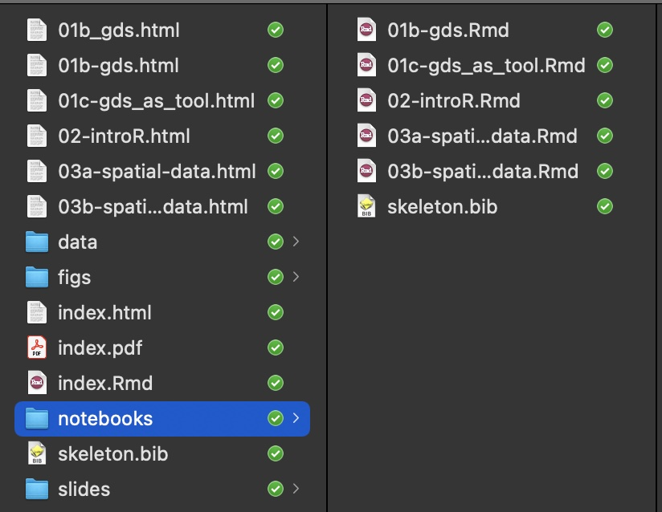

Fig. 1. Folder structure.

# Computational Environment

You need the most recent version of R and packages. These can be installed following the instructions provided in our [R installation guide](https://gdsl-ul.github.io/r_install/).

## Dependency list

The list of libraries that we will use is provided below. If you have followed the instructions provided in our [R installation guide](https://gdsl-ul.github.io/r_install/) and will be using Docker, you can relax and these libraries have already been installed for you.

If you have `natively` installed *R* and *RStudio*, you need to ensure you have installed the list of libraries used in this book following the steps provided [here](https://gdsl-ul.github.io/r_install/otherWin.html#install-packages).

- `arm`
- `car`
- `corrplot`
- `FRK`
- `gghighlight`
- `ggplot2`
- `ggpubr`
- `ggmap`
- `GISTools`
- `gridExtra`
- `gstat`
- `jtools`
- `kableExtra`
- `knitr`
- `lme4`
- `lmtest`
- `lubridate`
- `MASS`
- `merTools`
- `plyr`
- `RColorBrewer`
- `rgdal`
- `sf`
- `sjPlot`
- `sp`
- `spgwr`
- `spatialreg`
- `spacetime`
- `stargazer`
- `tidyverse`
- `tint`
- `tmap`
- `viridis`

You can get the materials from this course as a [download](https://github.com/fcorowe/udd_gds_course/archive/refs/heads/main.zip) of a .zip file or by going directly to the [GitHub repository](https://github.com/fcorowe/udd_gds_course).